# Taller 2 : Árboles de Decisión

**Nombres:**

- Diryon Yonith Mora Romero.
- Laura Valentina Gonzalez Rodriguez.

En este taller analizaremos aspectos de árboles de decisión para varios conjuntos de datos. El primero es el [Play tennis dataset](https://www.kaggle.com/datasets/fredericobreno/play-tennis). El segundo es el [Iris dataset](https://archive.ics.uci.edu/ml/datasets/iris). El tercero es el [Pima Indians Diabetes Database](https://www.kaggle.com/datasets/uciml/pima-indians-diabetes-database). El cuarto es [Hitters](https://www.kaggle.com/datasets/floser/hitters).

El taller consiste en realizar todas las tareas señaladas con #TO_DO. Se puede realizar de forma individual o en parejas.

Entregar el cuaderno ejecutado y guardado en formato .ipynb y en formato .html Cargarlo a más tardar el miércoles 22 de febrero en la actividad creada en aulas.

```python
#Importar librerías
import pandas as pd
from sklearn.datasets import load_iris
from sklearn.model_selection import cross_val_score
from sklearn.model_selection import train_test_split
from sklearn.tree import DecisionTreeClassifier, plot_tree, DecisionTreeRegressor
from sklearn import metrics
import matplotlib.pyplot as plt

import numpy as np
import math
```

## Calculando el mejor atributo para el Tennis Dataset

En primer lugar, cargar y leer el conjunto de datos Play Tennis, e imprimir todas sus filas (son pocas).

```python
#leer el Play tennis dataset.
df = pd.read_csv('play_tennis.csv').dropna()
#Mostrar todas sus filas.
df.info()
```

```
<class 'pandas.core.frame.DataFrame'>
RangeIndex: 14 entries, 0 to 13
Data columns (total 6 columns):
 #   Column    Non-Null Count  Dtype
---  ------    --------------  -----
 0   day       14 non-null     object
 1   outlook   14 non-null     object
 2   temp      14 non-null     object
 3   humidity  14 non-null     object
 4   wind      14 non-null     object
 5   play      14 non-null     object
dtypes: object(6)
memory usage: 800.0+ bytes
```

```python
#Verificar la codificación anterior
df.head()
```

|  | day | outlook | temp | humidity | wind | play |
| --- | --- | --- | --- | --- | --- | --- |
| 0 | D1 | Sunny | Hot | High | Weak | No |
| 1 | D2 | Sunny | Hot | High | Strong | No |
| 2 | D3 | Overcast | Hot | High | Weak | Yes |
| 3 | D4 | Rain | Mild | High | Weak | Yes |
| 4 | D5 | Rain | Cool | Normal | Weak | Yes |

**TO_DO 1** Clacular la ganancia de información para cada variable: $Gain(S,A)=Ent(S)-\sum_{v\in values(A)}\frac{|S_v|}{|S|}Ent(S_v)$

$Ent(S) = - \sum_{i=1}^{c}p_1Log_2p_i$

¿Cuál sería el mejor atributo para comenzar el árbol? Observación: Puede hacer sus cálculos a mano y adjuntar una imagen de los mismos, o programar.

S es la dataset. A son cada una de las Columnas. El mayor deberia ser en donde inicia el arbol. Decidir si se va a jugar tenis o no. Las etiquetas son si o no

```python
entropies = {}

for column in df.columns:
    n = df[column].count()
    value_counts = df[column].value_counts()
    pi = value_counts / n
    entropy = - (pi * (pi.apply(math.log2))).sum()
    entropies[column] = entropy
    print("La entropía de '{}' es: {:.4f}".format(column, entropy))

for column in df.columns[:-1]:
    grouped = df.groupby([column, 'play'])
    n_i = grouped.size()
    n_i_total = n_i.groupby(level=0).sum()
    pi_i = n_i / n_i_total
    entropy_i = - (pi_i * (pi_i.apply(math.log2))).groupby(level=0).sum()
    entropy = entropies[column]
    gain = entropy - (entropy_i * n_i_total / n).sum()
    print("La ganancia de información de la variable '{}' es: {:.4f}".format(column, gain))
```

```
La entropía de 'day' es: 3.8074
La entropía de 'outlook' es: 1.5774
La entropía de 'temp' es: 1.5567
La entropía de 'humidity' es: 1.0000
La entropía de 'wind' es: 0.9852
La entropía de 'play' es: 0.9403
La ganancia de información de la variable 'day' es: 3.8074
La ganancia de información de la variable 'outlook' es: 0.8839
La ganancia de información de la variable 'temp' es: 0.6456
La ganancia de información de la variable 'humidity' es: 0.2115
La ganancia de información de la variable 'wind' es: 0.0931
```

El dato con mayor ganancia es: *day = 3.8074*, el arbol de decisión debería iniciar ahí.

## Árbol de decisión para clasificación del Iris Dataset

Primero definimos el clasificador y lo entrenamos con el conjunto de datos de entrenamiento.

```python
#TO_DO 2 Importar el Iris Dataset usando load_iris de sklearn (ya se importó load_iris). Darle el nombre 'iris'.
# Guardar en X,y las variables de entrada y salida respectivamente, en tipo DataFrame.
# Usar iris.data, iris.target.

X = pd.DataFrame(load_iris().data, columns=["sepal_length", "sepal_width", "petal_length", "petal_width"])
y = pd.DataFrame(load_iris().target, columns=['target'])
#print(X,y)
```

```python
#TO_DO 3 Separar en Train y Test set con una proporción de 70%-30%.

X_train, X_test, y_train, y_test = train_test_split( X, y,test_size=0.30,random_state=0)
```

```python
#TO_DO 4 Definir un clasificador de árbol de decisión con DecisionTreeClassifier de SKLearn.
#Usar los parámetros random_state=0 y criterion='entropy'
#Entrenarlo

clf = DecisionTreeClassifier(random_state=0, criterion='entropy')
clf.fit(X_train, y_train)
```

```
DecisionTreeClassifier(criterion='entropy', random_state=0)
```

Medimos la precisión: la proporción entre predicciones correctas y el total de predicciones:

```python
y_pred = clf.predict(X_test)
print("Accuracy:",metrics.accuracy_score(y_test, y_pred))
```

```
Accuracy: 0.9777777777777777
```

**Plot** Graficamos el árbol obtenido mediante el uso de plot_tree. To_do 5 ¿Qué información identifica en el árbol?

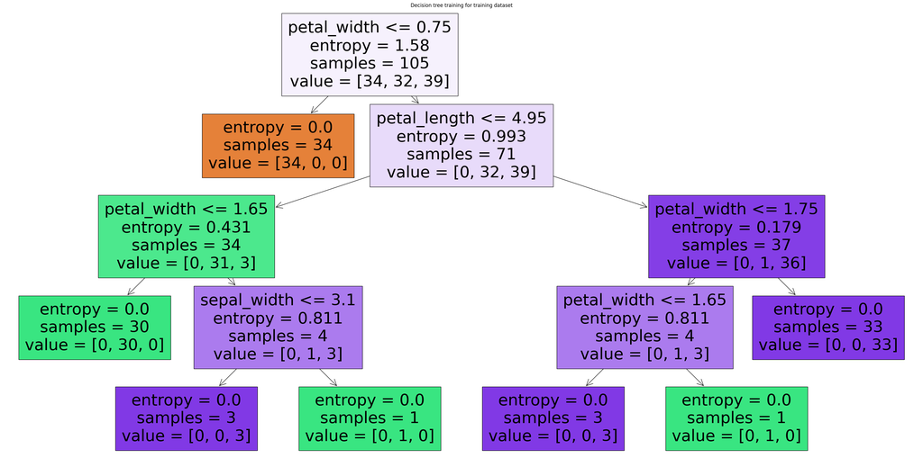

```python
plt.figure(figsize=(40,20))
plot_tree(clf, filled=True, feature_names=X.columns)
plt.title("Decision tree training for training dataset")
plt.show()
```

Podemos observar que toma el dato de *petal_width = x[3] < 0.75* para obtener la región 1 con 34 muestras. Luego utiliza *petal_length = x[2] < 4.95* para el lado izquiero, seguido de volver a *petal_width = x[3] < 1.65* para la región 2 con 30 muestras. A continuación utiliza *sepal_width = x [1] < 3.1* para definir la región 3 con 3 muestras y *sepal_width = x [1] >= 3.1* para la región 4 con 1 muestra. En el lado más derecho, continuando en *petal_length = x[2] >= 4.95*, se utiliza *petal_width = x[3] >= 1.75* para la región 7 con 33 muestras. Finalmente se toma *petal_width = x[3] < 1.65* para la región 5 con 3 muestras y *petal_width = x[3] >= 1.65* para la región 6 con 1 muestra. Obteniendo de la suma de las muestras de las regiones las 105 muestras iniciales.

**TO_DO 6**: Explore algunos métodos del DecisionTreeClassifier como apply, get_depth, get_n_leaves. Calcúlelos y corrobore su resultado usando el diagrama de árbol.

```python
# Aplicar métodos apply, get_depth, get_n_leaves y entender lo que dicen del árbol.

y_pred = clf.apply(X_test)
depth = clf.get_depth()
n_leaves = clf.get_n_leaves()

print(f"Profundidad del árbol: {depth}") # Cuenta los niveles sin tomar el inicial.
print(f"Número de hojas del árbol: {n_leaves}") # Da el mismo resultado que el numero de regiones.
print(f"Predicciones del modelo: {y_pred}")
```

```
Profundidad del árbol: 4
Número de hojas del árbol: 7
Predicciones del modelo: [12  4  1 12  1 12  1  4  4  4 10  4  4  4  4  1  4  4  1  1  6  4  1  1
  6  1  1  4  4  1 12  4  1  6 12  4  1 10  4  4 12  1 12  1  1]
```

## Diabetes Dataset

A continuación se entrenará un árbol de decisión para el conjunto de datos sobre diabetes.

**TO_DO 7**:

- Entrene un árbol de decisión utilizando el clasificador de SKLearn con un conjunto de entrenamiento del 80% del dataset. Utilice random_state=0 y el criterio de entropía.

**TO_DO 8**:

- Grafique el árbol. ¿Cuál es la precisión de este modelo?

```
Accuracy: 0.7077922077922078
```

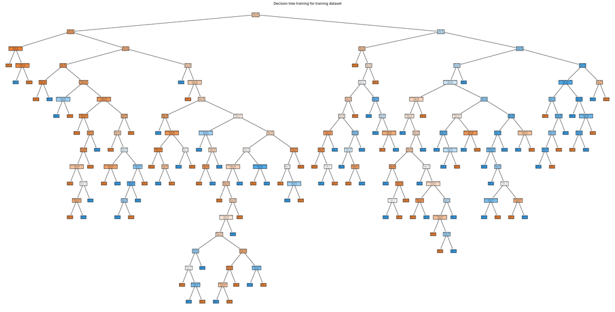

```python
## Su código aquí

df = pd.read_csv('diabetes.csv').dropna()

columnas = [z for z in df.columns if z != "Outcome"]
X = df[columnas].copy()
y = df.Outcome
X_train, X_test, y_train, y_test = train_test_split(X, y, test_size=0.2, random_state=0)

clf = DecisionTreeClassifier(criterion='entropy', random_state=0)
clf.fit(X_train, y_train)

y_pred = clf.predict(X_test)
print("Accuracy:",metrics.accuracy_score(y_test, y_pred))

plt.figure(figsize=(40,20))
plot_tree(clf, filled=True, feature_names=X.columns)
plt.title("Decision tree training for training dataset")
plt.show()
```

## Poda del árbol

Uno de los parámetros del DecisionTreeClassifier es *ccp_alpha*, el cual es un parámetro para la poda del árbol mediante el método *Mínimal cost complexity*. El código siguiente arroja una lista de valores de alpha que resultan efectivos en la poda del árbol.

Entre mayor es el valor de $\alpha$, más se poda el árbol.

```python
path = clf.cost_complexity_pruning_path(X_train, y_train)
ccp_alphas, impurities = path.ccp_alphas, path.impurities
ccp_alphas
```

```
array([0.        , 0.00325733, 0.00325733, 0.00325733, 0.00354114,
       0.00404381, 0.00434311, 0.00448679, 0.00448679, 0.00448679,
       0.00448679, 0.00448679, 0.00448679, 0.0046164 , 0.00468704,
       0.0048303 , 0.0048303 , 0.00495964, 0.00502633, 0.00522067,
       0.0052852 , 0.0055433 , 0.00560085, 0.00575644, 0.00587889,
       0.00594704, 0.00602679, 0.00604632, 0.00604745, 0.00605368,
       0.00618329, 0.00640444, 0.0064094 , 0.00654328, 0.00655698,
       0.00674546, 0.00684674, 0.00690069, 0.00697625, 0.00702367,
       0.00737675, 0.00768763, 0.00785562, 0.00787552, 0.00812098,
       0.00818056, 0.0086791 , 0.00869433, 0.00897357, 0.00914306,
       0.00924392, 0.00994398, 0.01118351, 0.01151191, 0.0120048 ,
       0.01282652, 0.02102938, 0.02130657, 0.0278788 , 0.03683399,
       0.04500223, 0.13153424])
```

**TO_DO 9:** Usando el arreglo de valores de *ccp_alpha* arrojados en la celda anterior, crear un loop que entrene un árbol para cada parámetro de ccp_alpha e imprima su precisión. ¿Cuál es el valor de ccp_alpha optimo?

```python
## código aquí

accuracy_list = []
for ccp_alpha in ccp_alphas:
    clf = DecisionTreeClassifier(criterion='entropy', random_state=0, ccp_alpha=ccp_alpha)
    clf.fit(X_train, y_train)
    y_pred = clf.predict(X_test)
    accuracy = metrics.accuracy_score(y_test, y_pred)
    accuracy_list.append(accuracy)
    print("ccp_alpha:", ccp_alpha, "Accuracy:", accuracy)

best_ccp_alpha = ccp_alphas[np.argmax(accuracy_list)]
print("Best ccp_alpha:", best_ccp_alpha)
```

```
ccp_alpha: 0.0 Accuracy: 0.7077922077922078
ccp_alpha: 0.003257328990228013 Accuracy: 0.7207792207792207
ccp_alpha: 0.003257328990228013 Accuracy: 0.7207792207792207
ccp_alpha: 0.003257328990228013 Accuracy: 0.7207792207792207
ccp_alpha: 0.003541136437782387 Accuracy: 0.7207792207792207
ccp_alpha: 0.004043812869416617 Accuracy: 0.7207792207792207
ccp_alpha: 0.004343105320304018 Accuracy: 0.7142857142857143
ccp_alpha: 0.004486787462806952 Accuracy: 0.7142857142857143
ccp_alpha: 0.004486787462806952 Accuracy: 0.7142857142857143
ccp_alpha: 0.004486787462806952 Accuracy: 0.7142857142857143
ccp_alpha: 0.004486787462806952 Accuracy: 0.7142857142857143
ccp_alpha: 0.004486787462806952 Accuracy: 0.7142857142857143
ccp_alpha: 0.004486787462806952 Accuracy: 0.7142857142857143
ccp_alpha: 0.0046163955311671785 Accuracy: 0.7142857142857143
ccp_alpha: 0.0046870367403543675 Accuracy: 0.7207792207792207
ccp_alpha: 0.0048302967486052156 Accuracy: 0.7207792207792207
ccp_alpha: 0.004830296748605221 Accuracy: 0.7207792207792207
ccp_alpha: 0.004959635958376633 Accuracy: 0.7207792207792207
ccp_alpha: 0.0050263295230949905 Accuracy: 0.7272727272727273
ccp_alpha: 0.005220674778766189 Accuracy: 0.7142857142857143
ccp_alpha: 0.005285199507877087 Accuracy: 0.7142857142857143
ccp_alpha: 0.005543302733648896 Accuracy: 0.7142857142857143
ccp_alpha: 0.005600847360405197 Accuracy: 0.7207792207792207
ccp_alpha: 0.005756438074987935 Accuracy: 0.7207792207792207
ccp_alpha: 0.005878893280841712 Accuracy: 0.7207792207792207
ccp_alpha: 0.00594704308534728 Accuracy: 0.7142857142857143
ccp_alpha: 0.0060267930677611395 Accuracy: 0.7142857142857143
ccp_alpha: 0.006046320073832434 Accuracy: 0.7142857142857143
ccp_alpha: 0.00604744634202081 Accuracy: 0.7272727272727273
ccp_alpha: 0.006053678869362694 Accuracy: 0.7272727272727273
ccp_alpha: 0.0061832869377229215 Accuracy: 0.7207792207792207
ccp_alpha: 0.006404437249300772 Accuracy: 0.7207792207792207
ccp_alpha: 0.006409400892539968 Accuracy: 0.7207792207792207
ccp_alpha: 0.006543278194560575 Accuracy: 0.7207792207792207
ccp_alpha: 0.006556977630964112 Accuracy: 0.7207792207792207
ccp_alpha: 0.006745455130417414 Accuracy: 0.7207792207792207
ccp_alpha: 0.006846737872456488 Accuracy: 0.7402597402597403
ccp_alpha: 0.006900690134768748 Accuracy: 0.7402597402597403
ccp_alpha: 0.006976252280378801 Accuracy: 0.7402597402597403
ccp_alpha: 0.0070236661112516655 Accuracy: 0.7402597402597403
```

[output cut: 8 more lines]

```
ccp_alpha: 0.008973574925613905 Accuracy: 0.7402597402597403
ccp_alpha: 0.009143064340913026 Accuracy: 0.7337662337662337
ccp_alpha: 0.009243915459318366 Accuracy: 0.7532467532467533
ccp_alpha: 0.009943975646005479 Accuracy: 0.7532467532467533
ccp_alpha: 0.011183514974848457 Accuracy: 0.7532467532467533
ccp_alpha: 0.011511908800140969 Accuracy: 0.7792207792207793
ccp_alpha: 0.012004800622679931 Accuracy: 0.7727272727272727
ccp_alpha: 0.012826517710630762 Accuracy: 0.7597402597402597
ccp_alpha: 0.021029382648115505 Accuracy: 0.7597402597402597
ccp_alpha: 0.021306568283758043 Accuracy: 0.7597402597402597
ccp_alpha: 0.02787879900735951 Accuracy: 0.7597402597402597
ccp_alpha: 0.036833986646986505 Accuracy: 0.7207792207792207
ccp_alpha: 0.04500222816035104 Accuracy: 0.7207792207792207
ccp_alpha: 0.1315342361726266 Accuracy: 0.6948051948051948
Best ccp_alpha: 0.011511908800140969
```

**TO_DO 10:** Entrenar un clasificador con el ccp_alpha óptimo. Graficarlo y compararlo con el árbol inicial.

```
Accuracy (Pruned tree): 0.7792207792207793
```

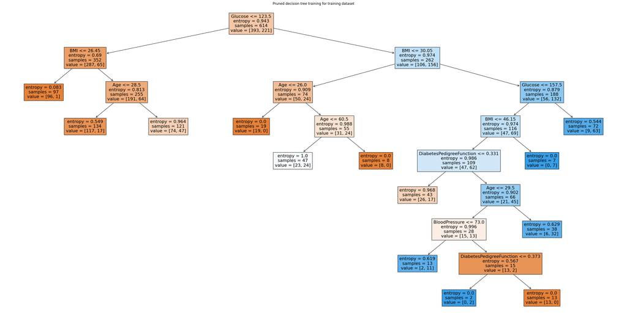

```python
clf_pruned = DecisionTreeClassifier(criterion='entropy', random_state=0, ccp_alpha=best_ccp_alpha)
clf_pruned.fit(X_train, y_train)

y_pred_pruned = clf_pruned.predict(X_test)
print("Accuracy (Pruned tree):",metrics.accuracy_score(y_test, y_pred_pruned))

plt.figure(figsize=(40,20))
plot_tree(clf_pruned, filled=True, feature_names=X.columns)
plt.title("Pruned decision tree training for training dataset")
plt.show()
```

Al seleccionar el ccp_alpha = 0.011511908800140969. Podemos notar una mejora notable en el arbol de decisión, no solo aumento su precisión de 0.7077922077922078 a 0.7792207792207793, sino que visualmente se nota como eliminar ciertas ramas contribuyó a evitar el sobreajuste y tener una información más clara.

## Árbol de regresión

Para éste ejercicio usamos el dataset de Hitters, cuya variable objetivo es el salario, el cual no es una variable categórica. Para esto necesitamos un árbol de regresión. A saber, DecisionTreeRegressor.

Primero leemos el dataset, y consideramos como entrada X únicamente dos de sus variables: Years, Hits. Tomamos como variable objetivo el salario.

```python
df = pd.read_csv('Hitters.csv').dropna()
df.info()
```

```
<class 'pandas.core.frame.DataFrame'>
Int64Index: 263 entries, 1 to 321
Data columns (total 20 columns):
 #   Column     Non-Null Count  Dtype
---  ------     --------------  -----
 0   AtBat      263 non-null    int64
 1   Hits       263 non-null    int64
 2   HmRun      263 non-null    int64
 3   Runs       263 non-null    int64
 4   RBI        263 non-null    int64
 5   Walks      263 non-null    int64
 6   Years      263 non-null    int64
 7   CAtBat     263 non-null    int64
 8   CHits      263 non-null    int64
 9   CHmRun     263 non-null    int64
 10  CRuns      263 non-null    int64
 11  CRBI       263 non-null    int64
 12  CWalks     263 non-null    int64
 13  League     263 non-null    object
 14  Division   263 non-null    object
 15  PutOuts    263 non-null    int64
 16  Assists    263 non-null    int64
 17  Errors     263 non-null    int64
 18  Salary     263 non-null    float64
 19  NewLeague  263 non-null    object
dtypes: float64(1), int64(16), object(3)
memory usage: 43.1+ KB
```

```python
X = df[['Years', 'Hits']] # Tomamos sólo dos de las columnas
y = df.Salary
```

**TO_DO 11** Entrenar un árbol de regresión en X,y con el parámetro max_leaf_nodes=3; usar el método score (coeficiente de determinación)para medir su desempeño, y graficarlo.

```python
## código aquí

clf = DecisionTreeRegressor(max_leaf_nodes=3)
clf.fit(X, y)
score = clf.score(X, y)
print("Score:", score)
```

```
Score: 0.43665573627391885
```

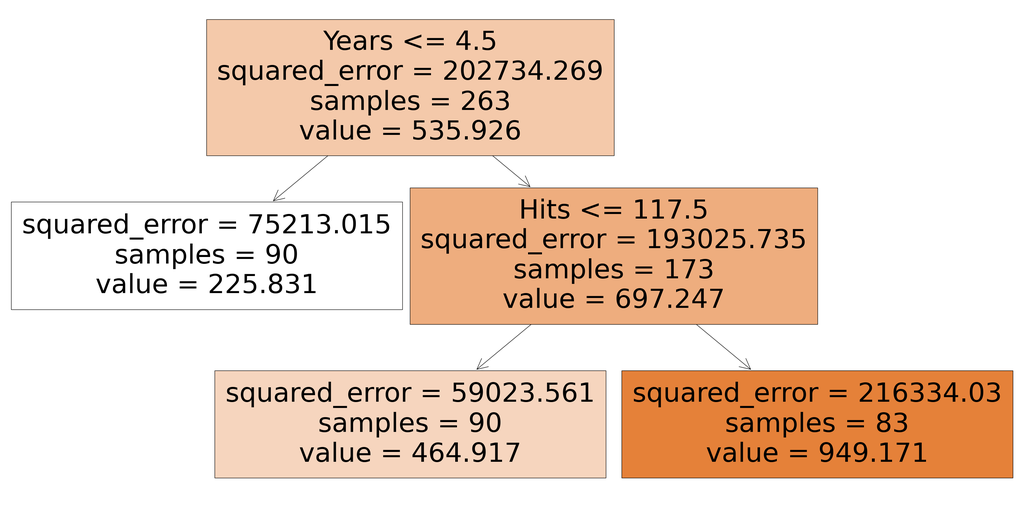

```python
## Graficar el árbol
plt.figure(figsize=(40,20))
plot_tree(clf, filled=True, feature_names=X.columns)
plt.show()
```

**TO_DO 12:** ¿En cuántas regiones $R_i$ separó el espacio de las dos variables de entrada el árbol anterior? Descríbalas.

El árbol anterior separó el espacio de las dos variables de entrada en tres regiones, cada una definida por una hoja del árbol. Las regiones son las siguientes:

$R_{1}$: Year < 4.5

$R_2$: Year >= 4.5 y hits < 117.5  
$R_3$: Year >= 4.5 y hits >= 117.5

Cada región tiene un valor de salida diferente, que corresponde al valor promedio de los salarios de los jugadores en esa región